# Taller 1: Ejercicios R base

Uso Avanzado de Sistemas de Información Geográfica

Autor/a

Afiliación

Dr. Francisco Zambrano

Escuela de Ingeniería en Medio Ambiente, Universidad Mayor

Fecha de publicación

25 de agosto de 2023

## 1 Lo básico

1. Escriba un programa en R para crear una secuencia de números del 20 al 50 y encuentre la media de los números del 20 al 60 y la suma de los números del 51 al 91.

**Código**

```r
seq(20,50)
```

```
 [1] 20 21 22 23 24 25 26 27 28 29 30 31 32 33 34 35 36 37 38 39 40 41 42 43 44
[26] 45 46 47 48 49 50
```

**Código**

```r
mean(20:60)
```

```
[1] 40
```

**Código**

```r
sum(51:91)
```

```
[1] 2911
```

2. Escriba un programa en R para crear una curva de campana de una distribución normal aleatoria

**Código**

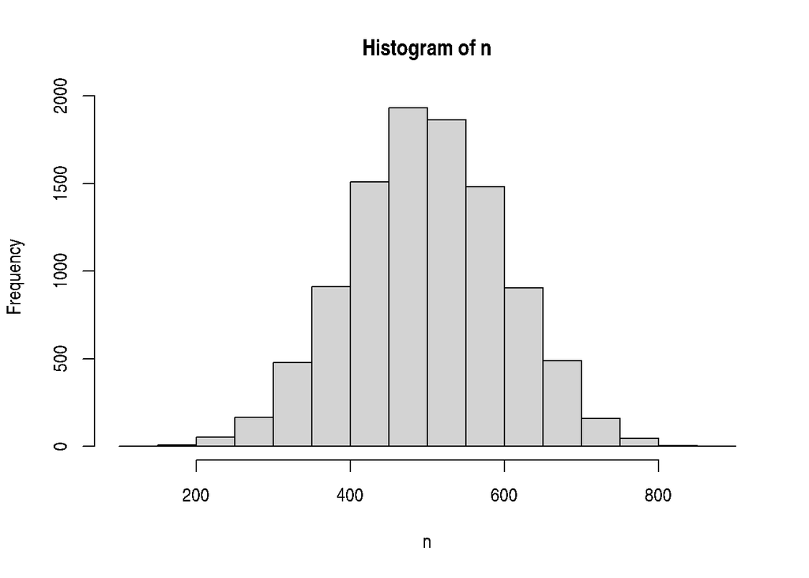

```r
n <- rnorm(10000, 500, 100)
hist(n)
```

3. Escriba un programa R para crear una lista de elementos usando vectores, matrices y funciones. Imprime el contenido de la lista.

**Código**

```r
l = list(
  c(1, 2, 2, 5, 7, 12),
  month.abb,
  matrix(c(3, -8, 1, -3), nrow = 2),
  asin
)
l
```

```
[[1]]
[1]  1  2  2  5  7 12

[[2]]
 [1] "Jan" "Feb" "Mar" "Apr" "May" "Jun" "Jul" "Aug" "Sep" "Oct" "Nov" "Dec"

[[3]]
     [,1] [,2]
[1,]    3    1
[2,]   -8   -3

[[4]]
function (x)  .Primitive("asin")
```

4. Escriba un programa en R para crear una matriz de 5 x 4, una matriz de 3 x 3 con etiquetas y rellene la matriz por filas y una matriz de 2 x 2 con etiquetas y rellene la matriz por columnas.

**Código**

```r
m1 <- matrix(1:20, nrow=5, ncol=4)
m1
```

```
     [,1] [,2] [,3] [,4]
[1,]    1    6   11   16
[2,]    2    7   12   17
[3,]    3    8   13   18
[4,]    4    9   14   19
[5,]    5   10   15   20
```

**Código**

```r
cells <- c(1,3,5,7,8,9,11,12,14)
rnames <- c("Row1", "Row2", "Row3")
cnames <- c("Col1", "Col2", "Col3")
m2 <- matrix(cells, nrow=3, ncol=3, byrow=TRUE, dimnames=list(rnames, cnames))
m2
```

```
     Col1 Col2 Col3
Row1    1    3    5
Row2    7    8    9
Row3   11   12   14
```

**Código**

```r
m3 <- matrix(cells, nrow=3, ncol=3, byrow=FALSE, dimnames=list(rnames, cnames))
m3
```

```
     Col1 Col2 Col3
Row1    1    7   11
Row2    3    8   12
Row3    5    9   14
```

5. Escriba un programa R para crear un `data.frame` que contenga detalles (genero, edad, rut, dirección, profesión) de 5 empleados y muestre un resumen de los datos.

**Código**

```r
empleados <- data.frame(Nombre=c("Joaquin","Josefina","Israel", "Esteban","Claudio"),
                      Genero = c("M","F","M","M","M"),
                      Edad = c(23,22,25,26,32),
                      Designation=c("CEO","CTO","Ejecutivo","CEO","Data Scientist"),
                      SSN = c("123-34-2346","123-44-779","556-24-433","123-98-987","679-77-576")
                      )
summary(empleados)
```

```
    Nombre             Genero               Edad      Designation
 Length:5           Length:5           Min.   :22.0   Length:5
 Class :character   Class :character   1st Qu.:23.0   Class :character
 Mode  :character   Mode  :character   Median :25.0   Mode  :character
                                       Mean   :25.6
                                       3rd Qu.:26.0
                                       Max.   :32.0
     SSN
 Length:5
 Class :character
 Mode  :character
```

## 2 Vectores

**Código**

```r
x <- vector("numeric", 5)
x
```

```
[1] 0 0 0 0 0
```

**Código**

```r
c <- vector("complex", 5)
c
```

```
[1] 0+0i 0+0i 0+0i 0+0i 0+0i
```

**Código**

```r
l <- vector("logical", 5)
l
```

```
[1] FALSE FALSE FALSE FALSE FALSE
```

**Código**

```r
chr <- vector("character", 5)
chr
```

```
[1] "" "" "" "" ""
```

2. Escriba un programa en R para sumar dos vectores de tipo entero y longitud 3.

**Código**

```r
x <- c(10, 20, 30)
y <- c(20, 10, 40)
x
```

```
[1] 10 20 30
```

**Código**

```r
y
```

```
[1] 20 10 40
```

**Código**

```r
z = x + y
z
```

```
[1] 30 30 70
```

4. Escriba un programa en R para encontrar la suma, la media y el producto de un vector.

**Código**

```r
x <- c(10, 20, 30)
sum(x)
```

```
[1] 60
```

**Código**

```r
mean(x)
```

```
[1] 20
```

**Código**

```r
prod(x)
```

```
[1] 6000
```

7. Escriba un programa R para encontrar la suma, la media y el producto de un vector, ignore elementos como NA o NaN.

**Código**

```r
x <- rnorm(10)
x[sample(1:10,2)] <- NA
x
```

```
 [1]         NA  1.1015374         NA  0.1602093 -0.3408991  0.4104385
 [7]  1.1998768  1.1411214  0.6306642  1.1904490
```

**Código**

```r
#una forma
mean(x,na.rm = TRUE)
```

```
[1] 0.6866747
```

**Código**

```r
sum(x,na.rm  =TRUE)
```

```
[1] 5.493398
```

**Código**

```r
prod(x,na.rm = TRUE)
```

```
[1] -0.02538274
```

**Código**

```r
#2da forma utilizando na.omit, que omite los NA de un vector o data.frame

x <- na.omit(x)
mean(x)
```

```
[1] 0.6866747
```

**Código**

```r
sum(x)
```

```
[1] 5.493398
```

**Código**

```r
prod(x)
```

```
[1] -0.02538274
```

8. Escriba un programa en R para ordenar un Vector en orden ascendente y descendente.

**Código**

```r
x
```

```
[1]  1.1015374  0.1602093 -0.3408991  0.4104385  1.1998768  1.1411214  0.6306642
[8]  1.1904490
attr(,"na.action")
[1] 1 3
attr(,"class")
[1] "omit"
```

**Código**

```r
sort(x)
```

```
[1] -0.3408991  0.1602093  0.4104385  0.6306642  1.1015374  1.1411214  1.1904490
[8]  1.1998768
```

**Código**

```r
sort(x,decreasing = TRUE)
```

```
[1]  1.1998768  1.1904490  1.1411214  1.1015374  0.6306642  0.4104385  0.1602093
[8] -0.3408991
```

9. Escriba un programa R para probar si un vector dado contiene un elemento específico.

**Código**

```r
x <- 1:10

5 %in% x
```

```
[1] TRUE
```

10. Escriba un programa R para encontrar el segundo valor más alto en un vector dado.

**Código**

```r
x <- round(rnorm(10)*10)
sort(x,decreasing = TRUE)[2]
```

```
[1] 19
```

11. Escriba un programa en R para encontrar el enésimo valor más alto en un vector dado.

**Código**

```r
n <- 5 #n esimo
sort(x,decreasing = TRUE)[n]
```

```
[1] 8
```

12. Escriba un programa en R para convertir la(s) columna(s) dada(s) de un `data.frame` en un vector.

**Código**

```r
v1 <- iris$Sepal.Length
v2 <- iris$Sepal.Width
v3 <- iris$Species
```

13. Escriba un programa R para encontrar los elementos de un vector dado que no están en otro vector dado.

**Código**

```r
v1 <- 1:5
v2 <- 3:7
v1;v2
```

```
[1] 1 2 3 4 5
```

```
[1] 3 4 5 6 7
```

**Código**

```r
#los elementos de v1 que no estan en v2
v1[!(v1 %in% v2)]
```

```
[1] 1 2
```

**Código**

```r
#los elementos de v2 que no estan en v1
v2[!(v2 %in% v1)]
```

```
[1] 6 7
```

14. Escriba un programa en R para invertir el orden del vector dado.

**Código**

```r
x <- 1:10
rev(x)
```

```
 [1] 10  9  8  7  6  5  4  3  2  1
```

15. Escriba un programa en R para crear un vector y encuentre la longitud y la dimensión del vector.

**Código**

```r
x <- 1:10
length(x)
```

```
[1] 10
```

**Código**

```r
dim(x)
```

[output not shown]

16. Escriba un programa R para probar si el valor del elemento de un vector dado es mayor que 10 o no. Devuelve `TRUE` o `FALSE`.

**Código**

```r
v <- 5:14
v[8]
```

```
[1] 12
```

**Código**

```r
v[8] > 10
```

```
[1] TRUE
```

17. Escriba un programa en R para sumar 3 a cada elemento en un vector dado. Imprime el vector original y el nuevo.

**Código**

```r
v <- 1:5
v + 3
```

```
[1] 4 5 6 7 8
```

18. Escriba un programa en R para crear un vector usando el operador : y la función seq().

**Código**

```r
v1 <- 1:10
v1
```

```
 [1]  1  2  3  4  5  6  7  8  9 10
```

**Código**

```r
v2 <- seq(1,10,2)
v2
```

```
[1] 1 3 5 7 9
```

## 3 Factors

1. Escriba un programa R para encontrar los niveles de factor de un vector dado.

**Código**

```r
levels(iris$Species)
```

```
[1] "setosa"     "versicolor" "virginica"
```

2. Escriba un programa R para cambiar el primer nivel de un factor con otro nivel de un factor dado.

**Código**

```r
letras <- factor(sample(letters[1:5],40,replace = TRUE))

levels(iris$Species)[1] <- levels(letras)[1]
levels(iris$Species)
```

```
[1] "a"          "versicolor" "virginica"
```

3. Escriba un programa en R para crear un factor ordenado a partir de datos que consisten en los nombres de los meses.

**Código**

```r
f <- factor(month.name, levels = month.name)
f
```

```
 [1] January   February  March     April     May       June      July
 [8] August    September October   November  December
12 Levels: January February March April May June July August ... December
```

4. Escriba un programa R para extraer los cinco niveles de factor creados a partir de una muestra aleatoria de las `letters` (parte de la distribución base R).

**Código**

```r
letras <- factor(letters[sample(1:5,20,replace = TRUE)])
levels(letras)
```

```
[1] "a" "b" "c" "d" "e"
```

5. Escriba un programa en R para crear un factor correspondiente al conjunto de datos de la altura de las mujeres, que contenga la altura y el peso de una muestra de mujeres.

**Código**

```r
data <- women
data
```

```
   height weight
1      58    115
2      59    117
3      60    120
4      61    123
5      62    126
6      63    129
7      64    132
8      65    135
9      66    139
10     67    142
11     68    146
12     69    150
13     70    154
14     71    159
15     72    164
```

**Código**

```r
height_f = cut(women$height,3)
table(height_f)
```

```
height_f
  (58,62.7] (62.7,67.3]   (67.3,72]
          5           5           5
```

## 4 Matrices

1. Escriba un programa en R para crear una matriz en blanco.

**Código**

```r
matrix(nrow=10,ncol=10)
```

```
      [,1] [,2] [,3] [,4] [,5] [,6] [,7] [,8] [,9] [,10]
 [1,]   NA   NA   NA   NA   NA   NA   NA   NA   NA    NA
 [2,]   NA   NA   NA   NA   NA   NA   NA   NA   NA    NA
 [3,]   NA   NA   NA   NA   NA   NA   NA   NA   NA    NA
 [4,]   NA   NA   NA   NA   NA   NA   NA   NA   NA    NA
 [5,]   NA   NA   NA   NA   NA   NA   NA   NA   NA    NA
 [6,]   NA   NA   NA   NA   NA   NA   NA   NA   NA    NA
 [7,]   NA   NA   NA   NA   NA   NA   NA   NA   NA    NA
 [8,]   NA   NA   NA   NA   NA   NA   NA   NA   NA    NA
 [9,]   NA   NA   NA   NA   NA   NA   NA   NA   NA    NA
[10,]   NA   NA   NA   NA   NA   NA   NA   NA   NA    NA
```

2. Escriba un programa en R para crear una matriz tomando como entrada un vector dado de números. Muestre la matriz.

**Código**

```r
v <- 1:9
matrix(v,3,3)
```

```
     [,1] [,2] [,3]
[1,]    1    4    7
[2,]    2    5    8
[3,]    3    6    9
```

3. Escriba un programa en R para crear una matriz que tome un vector dado de números como entrada y defina los nombres de columna y fila. Muestre la matriz.

**Código**

```r
v1 <- 1:9
m <- matrix(v1,3,3,dimnames = list(c('fila','fila2','fila3'),c('col1','col2','col3')))
m
```

```
      col1 col2 col3
fila     1    4    7
fila2    2    5    8
fila3    3    6    9
```

4. Escriba un programa en R para crear dos matrices de 2x3, luego sume, reste, multiplique y divida las matrices.

**Código**

```r
m1 <- matrix(1:6,2,3)
m2 <- matrix(6:1,2,3)
m1
```

```
     [,1] [,2] [,3]
[1,]    1    3    5
[2,]    2    4    6
```

**Código**

```r
m2
```

```
     [,1] [,2] [,3]
[1,]    6    4    2
[2,]    5    3    1
```

**Código**

```r
m1+m2
```

```
     [,1] [,2] [,3]
[1,]    7    7    7
[2,]    7    7    7
```

**Código**

```r
m1-m2
```

```
     [,1] [,2] [,3]
[1,]   -5   -1    3
[2,]   -3    1    5
```

**Código**

```r
m1*m2
```

```
     [,1] [,2] [,3]
[1,]    6   12   10
[2,]   10   12    6
```

**Código**

```r
m1/m2
```

```
          [,1]     [,2] [,3]
[1,] 0.1666667 0.750000  2.5
[2,] 0.4000000 1.333333  6.0
```

5. Escriba un programa en R para crear una matriz de correlación a partir de un `data.frame` del mismo tipo de datos.

**Código**

```r
cor(mtcars)
```

```
            mpg        cyl       disp         hp        drat         wt
mpg   1.0000000 -0.8521620 -0.8475514 -0.7761684  0.68117191 -0.8676594
cyl  -0.8521620  1.0000000  0.9020329  0.8324475 -0.69993811  0.7824958
disp -0.8475514  0.9020329  1.0000000  0.7909486 -0.71021393  0.8879799
hp   -0.7761684  0.8324475  0.7909486  1.0000000 -0.44875912  0.6587479
drat  0.6811719 -0.6999381 -0.7102139 -0.4487591  1.00000000 -0.7124406
wt   -0.8676594  0.7824958  0.8879799  0.6587479 -0.71244065  1.0000000
qsec  0.4186840 -0.5912421 -0.4336979 -0.7082234  0.09120476 -0.1747159
vs    0.6640389 -0.8108118 -0.7104159 -0.7230967  0.44027846 -0.5549157
am    0.5998324 -0.5226070 -0.5912270 -0.2432043  0.71271113 -0.6924953
gear  0.4802848 -0.4926866 -0.5555692 -0.1257043  0.69961013 -0.5832870
carb -0.5509251  0.5269883  0.3949769  0.7498125 -0.09078980  0.4276059
            qsec         vs          am       gear        carb
mpg   0.41868403  0.6640389  0.59983243  0.4802848 -0.55092507
cyl  -0.59124207 -0.8108118 -0.52260705 -0.4926866  0.52698829
disp -0.43369788 -0.7104159 -0.59122704 -0.5555692  0.39497686
hp   -0.70822339 -0.7230967 -0.24320426 -0.1257043  0.74981247
drat  0.09120476  0.4402785  0.71271113  0.6996101 -0.09078980
wt   -0.17471588 -0.5549157 -0.69249526 -0.5832870  0.42760594
qsec  1.00000000  0.7445354 -0.22986086 -0.2126822 -0.65624923
vs    0.74453544  1.0000000  0.16834512  0.2060233 -0.56960714
am   -0.22986086  0.1683451  1.00000000  0.7940588  0.05753435
gear -0.21268223  0.2060233  0.79405876  1.0000000  0.27407284
carb -0.65624923 -0.5696071  0.05753435  0.2740728  1.00000000
```

6. Escriba un programa R para encontrar el índice de fila y columna de valor máximo y mínimo en una matriz dada.

**Código**

```r
m <- matrix(sample(1:100,9),3,3)
which(m == max(m),arr.ind = TRUE)
```

```
     row col
[1,]   3   1
```

**Código**

```r
which(m == min(m),arr.ind = TRUE)
```

```
     row col
[1,]   1   2
```

7. Escriba un programa R para concatenar dos matrices dadas de la misma columna pero filas diferentes.

**Código**

```r
m1 <- matrix(sample(1:100,12),3,4)
m2 <- matrix(sample(1:100,20),5,4)

rbind(m1,m2)
```

```
     [,1] [,2] [,3] [,4]
[1,]   74   37   21   81
[2,]   95   94   57   97
[3,]   98   31   83   28
[4,]    6   94   33   70
[5,]   23   88   43   80
[6,]   53   14   84   18
[7,]   32   46   68   16
[8,]    3   59   78   21
```